# Batch correction

2022-08-13

# Batch effect correction

To integrate cells across samples, we can use computational strategies developed for correcting batch effects in single-cell RNA sequencing data. In the following sections, we will use functions of the [batchelor](https://www.bioconductor.org/packages/release/bioc/html/batchelor.html), harmony and [Seurat](https://satijalab.org/seurat/articles/integration_introduction.html) packages to correct for such batch effects.

We will only test harmony, as the other two took several days!!

Of note: the correction approaches presented here aim at removing any differences between samples. This will also remove biological differences between the patients/indications. Nevertheless, integrating cells across samples can facilitate the detection of cell phenotypes via clustering.

First, we will read in the `SpatialExperiment` object containing the single-cell data.

When a code chunk is time-consuming to run, you may consider caching it via the chunk option cache = TRUE. When the cache is turned on, `knitr` will skip the execution of this code chunk if it has been executed before and nothing in the code chunk has changed since then. This is explained in more detail [here](https://bookdown.org/yihui/rmarkdown-cookbook/cache.html). However cache=TRUE did not work and was computing batch correction anyway. Thus the chunk was commented.

```r
path <- "/mnt/Multimodal_Imaging_Daria/_Data_Analysis/_tmp_daria/Image_analysis/20220723_Steinbock_Mesmer_IFbased"
spe <- readRDS(file.path(path,"data/spe.rds"))
```

## harmony correction

The `harmony` algorithm performs batch correction by iteratively clustering and correcting the positions of cells in PCA space [@Korsunsky2019]. It requires a matrix of transformed expression counts and internally performs PCA before kmeans clustering. We will first create the expression matrix and call the `HarmonyMatrix` function to perform the correction.

Paper: [Fast, sensitive and accurate integration of single-cell data with Harmony](https://www.nature.com/articles/s41592-019-0619-0)  
Documentation: [harmony](https://portals.broadinstitute.org/harmony/index.html)

Similar to the `fastMNN` function, `harmony` returns the corrected low-dimensional coordinates for each cell. These can be saved in the `reducedDim` slot of the original `SpatialExperiment` object.

```r
#library(harmony)

#mat <- t(assay(spe, "exprs")[rowData(spe)$use_channel,])

#harmony_emb <- HarmonyMatrix(mat, spe$sample, do_pca = TRUE)

#reducedDim(spe, "harmony") <- harmony_emb
```

### Visualization

We will now again visualize the cells in low dimensions after UMAP embedding.

```r
#set.seed(220228)
#detectCores(all.tests = FALSE, logical = TRUE) # find out how many logical cores available
#spe <- runUMAP(spe, dimred = "harmony", name = "UMAP_harmony", BPPARAM = MulticoreParam())
```

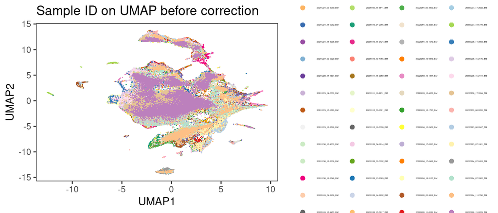

```r
# visualize sample

library(cowplot)
library(dittoSeq)
library(viridis)
library(RColorBrewer)

n <- length(metadata(spe)$color_vectors$sample)
qual_col_pals = brewer.pal.info[brewer.pal.info$category == 'qual',]
col_vector = unlist(mapply(brewer.pal, qual_col_pals$maxcolors, rownames(qual_col_pals)))

metadata(spe)$color_vectors$sample <- sample(col_vector, n)

p1 <- dittoDimPlot(spe, var = "sample",
                   reduction.use = "UMAP", size = 0.2, legend.size=2) +
    scale_color_manual(values = metadata(spe)$color_vectors$sample) +
    ggtitle("Sample ID on UMAP before correction") +
    theme(legend.text=element_text(size=2))
p2 <- dittoDimPlot(spe, var = "sample",
                   reduction.use = "UMAP_harmony", size = 0.2, legend.size=2) +
    scale_color_manual(values = metadata(spe)$color_vectors$sample) +
    ggtitle("Sample ID on UMAP after correction") +
    theme(legend.text=element_text(size=2))

plot_grid(p1)
```

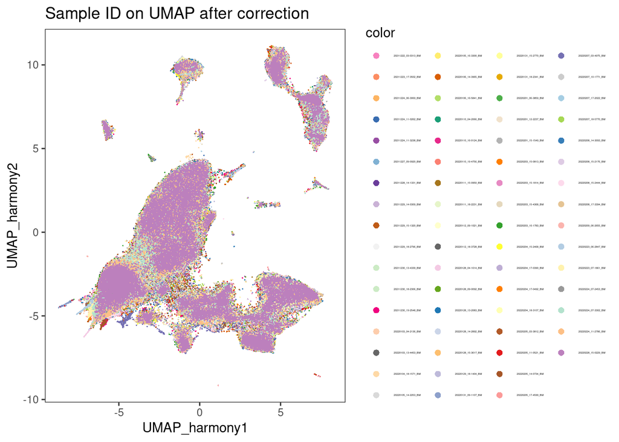

```r
plot_grid(p2)
```

And we visualize selected marker expression as defined above.

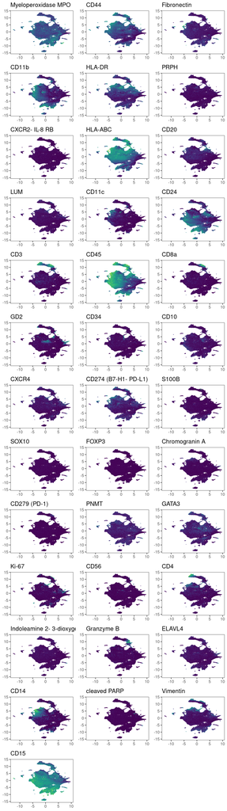

```r
# Before correction
plot_list <- multi_dittoDimPlot(spe, var = rownames(spe)[rowData(spe)$use_channel], reduction.use = "UMAP",
                   assay = "exprs", size = 0.2, list.out = TRUE)
plot_list <- lapply(plot_list, function(x) x + scale_color_viridis())
plot_grid(plotlist = plot_list, nrow=13, ncol=3)
```

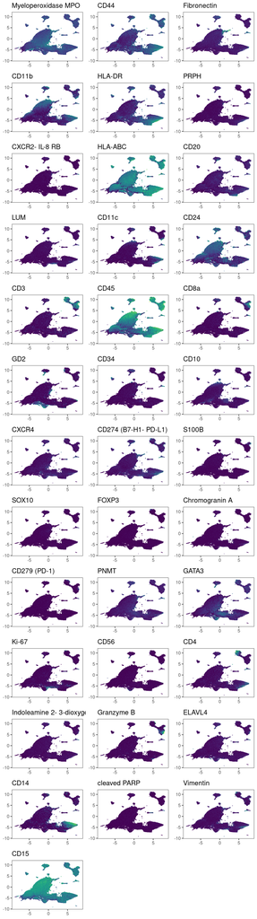

```r
# After correction
plot_list <- multi_dittoDimPlot(spe, var = rownames(spe)[rowData(spe)$use_channel], reduction.use = "UMAP_harmony",
                   assay = "exprs", size = 0.2, ncol=3, nrow=13, list.out = TRUE)
plot_list <- lapply(plot_list, function(x) x + scale_color_viridis())
plot_grid(plotlist = plot_list, nrow=13, ncol=3)
```

## Seurat correction

Seurat and fastMNN were tested but required too much computing time (several days), and were stopped in the end.

Use plan(“multicore”) to parallelize Seurat and adjust `future.globals.maxSize` if required, as explained [here](https://www.rdocumentation.org/packages/future/versions/1.26.1/topics/future.options).

Choosing the correct integration approach is challenging without having ground truth cell labels available. It is recommended to compare different techniques and different parameter settings. Please refer to the documentation of the individual tools to become familiar with the possible parameter choices. Furthermore, in the following section, we will discuss clustering and classification approaches in light of expression differences between samples.

## Save objects

The modified `SpatialExperiment` object is saved for further downstream analysis.

```r
saveRDS(spe, file.path(path, "data/spe.rds"))
```